# STAT 184 Final Project

# write to working directory

```r
write.table(lyrics1980to2019, "lyrics1980to2019.txt", sep =' ', col.names = T, row.names = FALSE )
```

# data set with all lyrics, separate the words

```r
verse_words <- lyrics1980to2019 %>%
  unnest_tokens(word, lyric)
```

# data set without stop_word and 11 words

```r
# filter out stop_words
ft <- verse_words %>%
  anti_join(stop_words)
# filter out the 11 words
ft_stop_11 <- ft %>%
  filter(!word %in% c("ba", "du", "yeah", "da", "ya", "ooh", "gonna", "na", "uh", "la", "hol"))
```

# Code explanation

# To create the data frame of filtered out stop words (stop_words and the 11 words), I first need to get the raw data from Wikipedia, by getting the xpaths for tables of four decades, and create four data frames correspondingly. Then I joined them together one by one using function full_join() with the NAs removed using function na.omit(). After that, I removed the unwanted column ‘Production team’ by using the NULL command. Then I renamed the variables to “year”, “track”, and artist" by using names() <- c() command. To remove the brackets in the year column, I used substr() to only preserve the first 4 characters. Now, I added the lyrics using add_genius(). To filter out the unwanted words, I first separate the lyrics into rows for each word, then I used function anti_join() to remove words in stop_wrods, and then I filtered out those unwanted 11 words by using filter(!word %in% c()), then the final data frame will have the remaining words in rows.

### Data Visualization

## 1

# adding decades without filtering out stop_words, 11 words

```r
lyrics1980to2019_80s <- verse_words %>%
  filter(year %in% (1980:1989)) %>%
  mutate(decade = "1980s")

lyrics1980to2019_90s <- verse_words %>%
  filter(year %in% (1990:1999)) %>%
  mutate(decade = "1990s")

lyrics1980to2019_00s <- verse_words %>%
  filter(year %in% (2000:2009)) %>%
  mutate(decade = "2000s")

lyrics1980to2019_10s <- verse_words %>%
  filter(year %in% (2010:2019)) %>%
  mutate(decade = "2010s")

lyrics1980to2019_80sto90s <- lyrics1980to2019_80s %>%
  full_join(lyrics1980to2019_90s)
lyrics1980to2019_80sto00s <- lyrics1980to2019_80sto90s %>%
  full_join(lyrics1980to2019_00s)
lyrics1980to2019_80sto10s <- lyrics1980to2019_80sto00s %>%
  full_join(lyrics1980to2019_10s)
lyrics1980to2019_80sto10s_3variables = lyrics1980to2019_80sto10s %>%
  group_by(track, decade) %>%
  count
```

# Graph 1

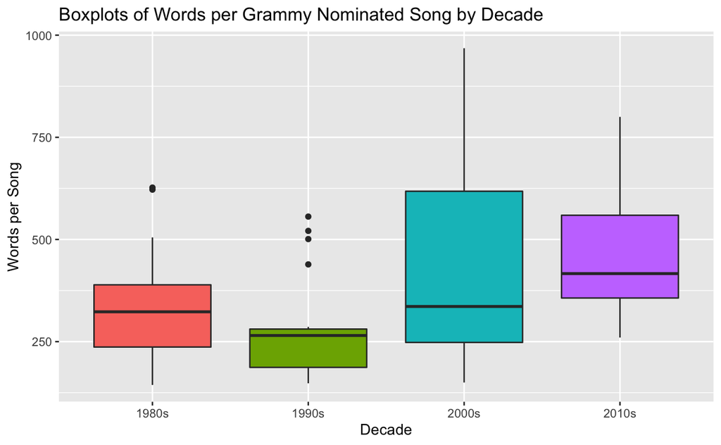

```r
lyrics1980to2019_80sto10s_3variables %>%
  ggplot(aes(x = decade, y = n, fill = decade))+
  geom_boxplot()+
  theme(legend.position = "none") +
  labs(x = "Decade", y = "Words per Song", title = "Boxplots of Words per Grammy Nominated Song by Decade")
```

# Interpretation: This graph compared the number of words for each song that was nominated in the Grammy Awards in each decade. We can see the graph shows 4 boxplots for 4 decades, each colored region represents the middle 50% of words per song in each decade, with the line inside it showing the median of words per song in that decade, the lower and upper 25% are shown by straight lines, and outliers are shown in dots. For example, the 2000s has the widest range of words per song, while the 1990s has the least median of words per song and the smallest middle 50%, but the 1990s has the most outliers that some songs have a large number of words. Overall, the words per song are increasing in terms of minimum, median, and the 25th percentile from the 1990s to 2010s.

## 2

# Graph 2 (“heart” and “world” have the same count)

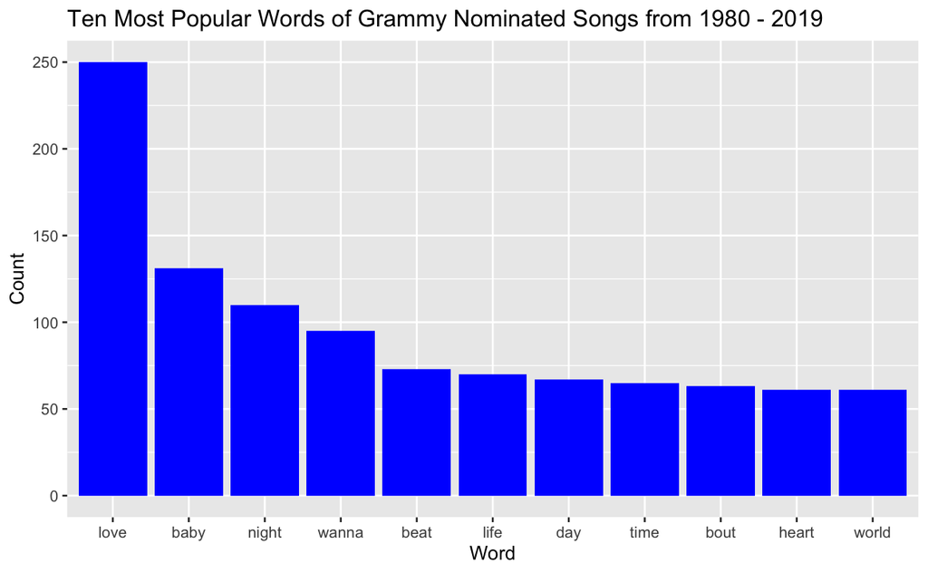

```r
Graph2topten <- ft_stop_11 %>%
  count(word, sort = TRUE) %>%
  filter(n >= 3) %>%
  top_n(10)
Graph2topten %>%
  ggplot(aes(x = reorder(word, -n), y = n)) +
  geom_col(fill = "blue")+
  labs(y = "Count", x = "Word", title = "Ten Most Popular Words of Grammy Nominated Songs from 1980 - 2019")
```

# Interpretation: This column graph shows the top ten most popular words from 1980 to 2019 in songs that were nominated in the Grammy Awards with the counts shown in descending order. We can see the graph shows “love” is the most popular word in this period with 250 times occurred, and down to “heart” and “world”, which have the same count, have 61 times occurred. Also from this graph, we can see “love” has a large exceed than the second favorite word, “baby”, and other words.

## 3

# adding decades for data frame of each decade without stop_words and 11 words

```r
lyrics1980to2019_80s_filtered <- ft_stop_11 %>%
  filter(year %in% (1980:1989)) %>%
  mutate(decade = "1980s")

lyrics1980to2019_90s_filtered <- ft_stop_11 %>%
  filter(year %in% (1990:1999)) %>%
  mutate(decade = "1990s")

lyrics1980to2019_00s_filtered <- ft_stop_11 %>%
  filter(year %in% (2000:2009)) %>%
  mutate(decade = "2000s")

lyrics1980to2019_10s_filtered <- ft_stop_11 %>%
  filter(year %in% (2010:2019)) %>%
  mutate(decade = "2010s")
```

# table 3.1

```r
Graph3topten80s <- lyrics1980to2019_80s_filtered %>%
  count(word, sort = TRUE) %>%
  filter(n >= 3) %>%
  top_n(10)
```

# table 3.2

```r
Graph3topten90s <- lyrics1980to2019_90s_filtered %>%
  count(word, sort = TRUE) %>%
  filter(n >= 3) %>%
  top_n(10)
```

# table 3.3

```r
Graph3topten00s <- lyrics1980to2019_00s_filtered %>%
  count(word, sort = TRUE) %>%
  filter(n >= 3) %>%
  top_n(10)
```

# table 3.4

```r
Graph3topten10s <- lyrics1980to2019_10s_filtered %>%
  count(word, sort = TRUE) %>%
  filter(n >= 3) %>%
  top_n(10)
```

# Graph 3.1

```r
Graph3.1 <- Graph3topten80s %>%
  ggplot(aes(x = reorder(word, -n), y = n)) +
  geom_col(fill = "blue") +
  theme(axis.text.x = element_text(angle = 45)) +
  labs(y = "Count", x = "Word", title = "1980s")
```

# Graph 3.2

```r
Graph3.2 <- Graph3topten90s %>%
  ggplot(aes(x = reorder(word, -n), y = n)) +
  geom_col(fill = "red") +
  theme(axis.text.x = element_text(angle = 45)) +
  labs(y = "Count", x = "Word", title = "1990s")
```

# Graph 3.3

```r
Graph3.3 <- Graph3topten00s %>%
  ggplot(aes(x = reorder(word, -n), y = n)) +
  geom_col(fill = "pink") +
  theme(axis.text.x = element_text(angle = 45)) +
  labs(y = "Count", x = "Word", title = "2000s")
```

# Graph 3.4

```r
Graph3.4 <- Graph3topten10s %>%
  ggplot(aes(x = reorder(word, -n), y = n)) +
  geom_col(fill = "grey") +
  theme(axis.text.x = element_text(angle = 45)) +
  labs(y = "Count", x = "Word", title = "2010s")
```

# Final Graph 3

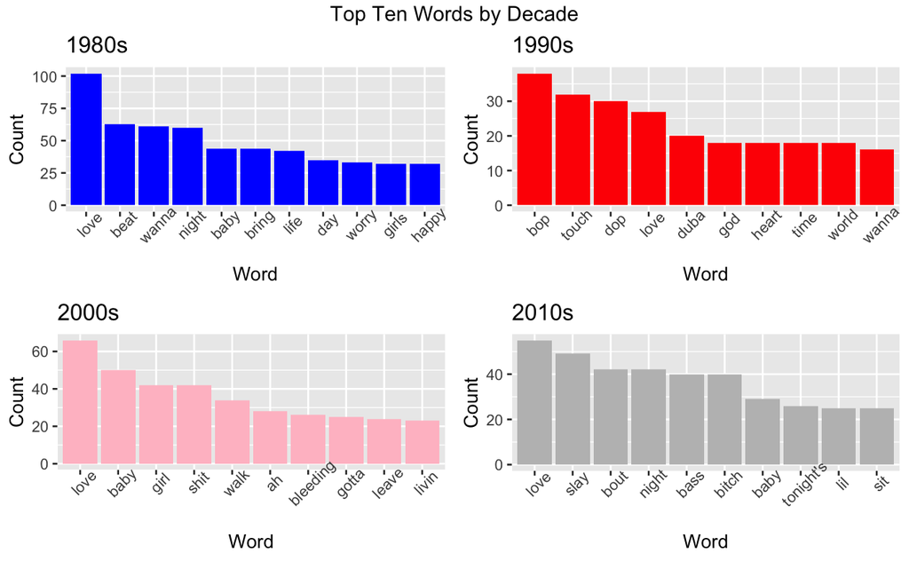

```r
Graph3 <-
  grid.arrange(Graph3.1, Graph3.2, Graph3.3, Graph3.4, top = "Top Ten Words by Decade")
```

# Interpretation: This graph is a combination of 4 bar charts indicate the top 10 words and the count in descending order from 1980 to 2019, with each decade separated. We can see “love” is the number one used word in the 1980s, 2000s, and 2010s. And “love” used in the 1980s has the largest number, with 102 times used.

## 4

# join tables of 4 decades with stop_words, 11 words filtered out

```r
lyrics1980to2019_80sto90s_filtered <- lyrics1980to2019_80s_filtered %>%
  full_join(lyrics1980to2019_90s_filtered)
lyrics1980to2019_80sto00s_filtered <- lyrics1980to2019_80sto90s_filtered %>%
  full_join(lyrics1980to2019_00s_filtered)
lyrics1980to2019_80sto10s_filtered <- lyrics1980to2019_80sto00s_filtered %>%
  full_join(lyrics1980to2019_10s_filtered)
```

# apply sentiment

```r
lyrics1980to2019_80sto10s_filtered_sentiments <- lyrics1980to2019_80sto10s_filtered %>%
  inner_join(sentiments)
```

# change positive sentiment to 1, negative sentiment to 0

```r
lyrics1980to2019_80sto10s_filtered_sentiments_1_0 <- lyrics1980to2019_80sto10s_filtered_sentiments %>%
  mutate(sentiment_score = case_when(.$sentiment == "positive" ~ 1, .$sentiment=="negative" ~ 0))
```

# find the net sentiment by filtering out negative sentiment

```r
lyrics1980to2019_80sto10s_filtered_sentiments_1_0_net <- lyrics1980to2019_80sto10s_filtered_sentiments_1_0 %>%
  filter(sentiment_score == "1")
```

# Graph 4

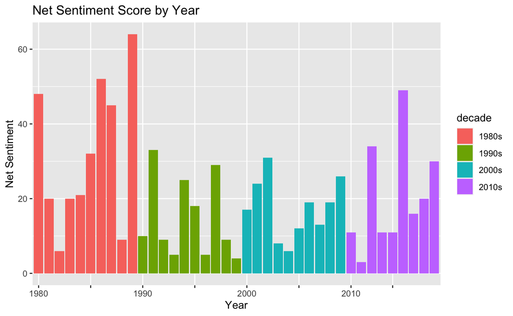

```r
ggplot(lyrics1980to2019_80sto10s_filtered_sentiments_1_0_net) +
  aes(x = year, fill = decade) +
  geom_bar() +
  labs(x = "Year", y = "Net Sentiment", title = "Net Sentiment Score by Year") +
  scale_x_discrete(breaks=c(1980, 1985, 1990, 1995, 2000, 2005, 2010, 2015, 2020), labels=c("1980", "", "1990", "", "2000", "", "2010", "", "2020"))
```